# Assignment 5

Paolo Mariani 800307

# Reinforcement Learning Assignment

Fornito il seguente grafo:

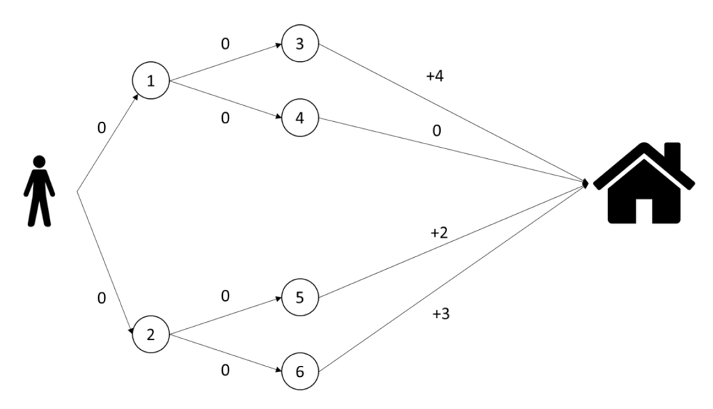

e la seguente policy iniziale $\pi_0$:

- $S_0 \rightarrow S_2$
- $S_2 \rightarrow S_5$
- $S_1 \rightarrow S_4$
- $S_3/S_4/S_5/S_6 \rightarrow S_{casa}$

si vogliono risolvere i seguenti quesiti:

1. Calcola il valore della funzione $V^{\pi_0}$ per ogni stato
2. Migliora la policy per ottenere quella nuova $\pi_1$
3. Calcola il valore della funzione $V^{\pi_1}$ per ogni stato
4. Migliora nuovamente la policy per ottenere quella nuova $\pi_2$
5. Stabilisci se la policy $\pi_2$ è quella ottimale

Si definisce **MDP (Processo Decisionale di Markov)** un framework matematico che permette di modellare un processo decisionale di ottimizzazione risolvibile con la programmazione dinamica e l’apprendimento per rinforzo, molto utile per problemi legati alla robotica, automazione e produzione industriale.  
Il caso proposto è un MDP finito, ossia un Processo decisionale di Markov in cui il numero di stati ed azioni che un agente può compiere è limitato;  
Nello specifico l’agente (una persona) è inserito in un ambiente composto da differenti cammini che permettono di raggiungere l’abitazione situata alla fine del grafo: esistono 4 diversi cammini che possono essere percorsi in funzione delle scelte che vengono effettuate ad ogni nodo.  
Ad ogni azione che viene compiuta si associa un “reward”, cioè un premio che viene fornito all’agente per aver scelto l’azione intrapresa: l’obiettivo è quello di massimizzare la somma dei reward ottenuti dall’agente lungo il raggiungimento dell’abitazione.  
Un MDP è caratterizzato dalle seguenti componenti:

- $S$: lo spazio degli Stati in cui l’agente può trovarsi
- $A$: lo spazio delle azioni che l’agente può compiere
- $T$: la matrice delle transizioni $T(s,a,s')$
- $R(s,a)$: la funzione che restituisce il reward per aver compiuto l’azione

Lo scoppo è determinare, per ogni stato, la transizione ottimale che massimizza i reward e genera di conseguenza la policy ottimale $\pi^*$.

Analizzando l’ambiente in cui è inserito l’agente si nota che esistono 8 diversi stati:

- lo stato iniziale $S_0$ e gli stati $S_1$ e $S_2$ in cui si può prendere una scelta sul cammino da percorrere
- gli stati $S_3$, $S_4$, $S_5$ e $S_6$ in cui l’unica scelta possibile è proseguire fino all’abitazione
- lo stato finale $S_{casa}$

**NB**: a tutti gli stati viene associata una reward pari al peso che è posizionato sugli archi che li collegano, nello specifico agli stati $S_3$, $S_4$, $S_5$ e $S_6$ viene associato il reward situato sul cammino che li collega al nodo $S_{casa}$: di conseguenza anche il valore della State Value Function sarà identico il loro reward.

L’algoritmo utilizzato che permette di valutare la policy migliore è quello della **Policy Iteration**: valuta una policy e ne suggerisce un improvement fino al raggiungimento della policy ottimale:

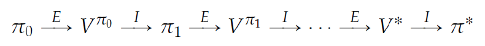

La valutazione della policy viene effettuata calcolando per ogni stato considerato la relativa **State Value Function** (sulla base dell’equazione di Bellman); questa funzione è composta da:

- $R(s,\pi(s))$: reward associata allo stato ottenuta applicando una politica $\pi_i$
- $\gamma$: fattore di sconto (per semplicità uguale a 1)
- ($\tau(s,a,s')$): funzione di transizione che permette di spostarsi da uno stato all’altro tramite una azione $a$
- $\sum_{s' \in S} \tau(s,\pi(a),s') * V^{\pi}(s')$: indica l’utilità di tutti gli stati successivi raggiungibili tramite le relative funzioni di transizione

La funzione è così definita:

$V^{\pi}(s') = R(s,\pi(s)) + \gamma \sum_{s' \in S} \tau(s,\pi(a),s') * V^{\pi}(s')$

Da questa funzione è possibile determinare la policy ottima che sarà restituita dall’algoritmo di **Policy Iteration**:

$\pi^*(s) = argmax_{a \in A}[R(s,a) + \gamma \sum_{s' \in S} \tau(s,a,s') * V^*(s')]$

# 1) Calcola il valore della funzione $V^{\pi_0}$ per ogni stato

La policy $\pi_0$ viene così rappresentata sul grafo:

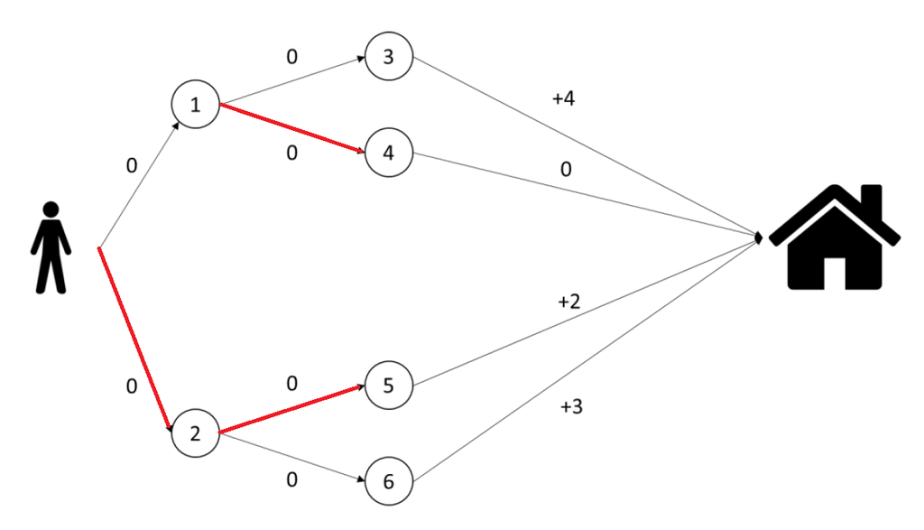

Il valore di $V^{\pi_0}$ per gli stati $S_3$, $S_4$, $S_5$ e $S_6$ è noto ed uguale alla reward ad essi associata:

- $S_3 = 4$
- $S_4 = 0$
- $S_5 = 2$
- $S_6 = 3$

Per gli altri stati $S_0$, $S_1$ e $S_2$ invece vale:

- $S_0 = 2$ dato da $(S_0\to S_2 + S_2\to\ S_5)$
- $S_1 = 0$ dato da $(S_1\to S_4)$
- $S_2 = 2$ dato da $(S_2\to S_5)$

Per determinare se esistono dei percorsi alternativi più remunerativi si calcola il valore della funzione SVF per ogni stato in cui viene effettuata una scelta: il primo argomento consiste in un cammino-proposta alternativa alla policy $\pi_0$, il secondo è il cammino raccomandato dalla policy.  
Si procede con il calcolo del valore della funzione State Value Function (SVF) per gli stati $S_0$, $S_1$ e $S_2$:

1. Stato 0:  
   $max\{(S_0\to S_1 + S_1\to\ S_4) ; (S_0\to S_2 + S_2\to\ S_5)\} = max\{(0+0+0); (0+0+2)\} = max\{0;2\} = 2$  
   La scelta ideale risulta ancora quella suggerita dalla policy $\pi_0:S_ 0 \to S_2$
2. Stato 1:  
   $max\{(S_1\to S_3) ; (S_1\to S_4)\} = max\{(0+4); (0+0)\} = max\{4;0\} = 4$  
   La scelta ideale risulta l’alternativa all’azione suggerita dalla policy $\pi_0: S_1 \to S_3$
3. Stato 2:  
   $max\{(S_2\to S_6) ; (S_2\to S_5)\} = max\{(0+3); (0+2)\} = max\{3;2\} = 3$  
   La scelta ideale risulta l’alternativa all’azione suggerita dalla policy $\pi_0: S_2 \to S_6$

**NB** il valore di utilità degli stati $S_3$, $S_4$, $S_5$ e $S_6$ equivale alla reward associata agli stati

# 2) Migliora la policy per ottenere quella nuova $\pi_1$

La nuova policy $\pi_1$ viene generata sostituendo alle azioni della policy $\pi_0$ le azioni più remunerative in termini di reward:  
$\pi_1$:

- $S_0 \rightarrow S_2$
- $S_1 \rightarrow S_3$
- $S_2 \rightarrow S_6$
- $S_3/S_4/S_5/S_6 \rightarrow S_{casa}$

Graficamente $\pi_1$ viene così rappresentata:

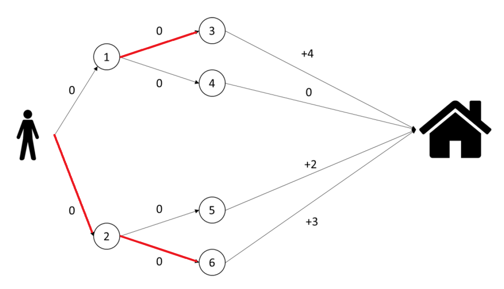

# 3) Calcola il valore della funzione $V^{\pi_1}$ per ogni stato

Il valore di $V^{\pi_1}$ per gli stati $S_3$, $S_4$, $S_5$ e $S_6$ è noto ed uguale alla reward ad essi associata:

- $S_3 = 4$
- $S_4 = 0$
- $S_5 = 2$
- $S_6 = 3$

Per gli altri stati $S_0$, $S_1$ e $S_2$ invece vale:

- $S_0 = 3$ dato da $(S_0\to S_2 + S_2\to\ S_6)$
- $S_1 = 4$ dato da $(S_1\to S_3)$
- $S_2 = 3$ dato da $(S_2\to S_6)$

Per determinare se esistono dei percorsi alternativi più remunerativi si calcola il valore della funzione SVF per ogni stato in cui viene effettuata una scelta.  
Si procede con la seconda iterazione dell’algoritmo Policy Iterator considerando la policy $\pi_1$ per gli stati $S_0$, $S_1$ e $S_2$:

1. Stato 0:  
   $max\{(S_0\to S_1 + S_1\to\ S_3) ; (S_0\to S_2 + S_2\to\ S_6)\} = max\{(0+0+4); (0+0+3)\} = max\{4;3\} = 4$  
   La scelta ideale risulta l’alternativa all’azione suggerita dalla policy $\pi_1: S_0 \to S_1$
2. Stato 1:  
   $max\{(S_1\to v4) ; (S_1\to S_3)\} = max\{(0+0); (0+4)\} = max\{0;4\} = 4$  
   La scelta ideale risulta ancora quella suggerita dalla policy $\pi_1: S_1 \to S_3$
3. Stato 2:  
   $max\{(S_2\to S_5) ; (S_2\to S_6)\} = max\{(0+2); (0+3)\} = max\{2;3\} = 3$  
   La scelta ideale risulta ancora quella suggerita dalla policy $\pi_1: S_2 \to S_6$

# 4) Migliora nuovamente la policy per ottenere quella nuova $\pi_2$

La nuova policy $\pi_2$ viene generata sostituendo alle azioni della policy $\pi_1$ le azioni più remunerative in termini di reward:  
$\pi_2$:

- $S_0 \rightarrow S_1$
- $S_1 \rightarrow S_3$
- $S_2 \rightarrow S_6$
- $S_3/S_4/S_5/S_6 \rightarrow S_{casa}$

Graficamente la nuova policy $\pi_2$ viene così rappresentata:

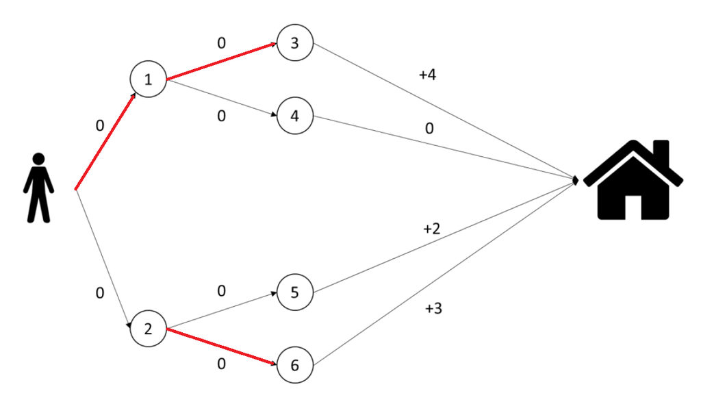

# 5) Stabilisci se la policy $\pi_2$ è quella ottimale

La policy $\pi_2$ risulta essere la policy ottimale in quanto non esistono altre azioni nel grafico che sono più remunerative di quelle che essa raccomanda, inoltre al suo interno è contenuta la sequenza ottimale che permette di massimizzare la reward partendo dallo stato $S_0$ fino allo stato $S_{casa}$ con valore di reward cumulata associato pari a 4 : $(S_0\to S_1 + S_1\to\ S_3 + S_3 \to S_{casa})$ .  
Per questo motivo si stabilisce di interrompere l’esecuzione dell’algoritmo Policy Iteration in quanto una nuova iterazione confermerebbe l’ottimalità della policy $\pi_2$ per il problema considerato.